# Exploring Weather Trends

**Author:** Felipe Millacura

Your submission should be a PDF that includes:

```
An outline of steps taken to prepare the data to be visualized in the chart, such as:
    What tools did you use for each step? (Python, SQL, Excel, etc)
    How did you calculate the moving average?
    What were your key considerations when deciding how to visualize the trends?
Line chart with local and global temperature trends
At least four observations about the similarities and/or differences in the trends
```

## Extracting the SQL Data

In order to extract global data

```
SELECT *
FROM global_data
```

```
SELECT year, avg_temp, city, country
FROM city_data
WHERE country = 'United Kingdom'
OR country = 'Chile'
OR country = 'Japan'
OR country = 'Australia'
OR country = 'South Africa'
```

## Analysing in Python

```python
# Imports libraries

import pandas as pd
import matplotlib.pyplot as plt
```

```python
# Imports data

global_data = pd.read_csv('./global_data.csv')

cities_data = pd.read_csv('./five_countries.csv')
```

```python
#Calculates rolling windows

global_data['MA7'] = global_data['avg_temp'].rolling(7, min_periods=7).mean()

global_data['MA14'] = global_data['avg_temp'].rolling(14, min_periods=14).mean()

global_data.set_index('year')
```

| year | avg_temp | MA7 | MA14 |
| --- | --- | --- | --- |
| 1750 | 8.72 | NaN | NaN |
| 1751 | 7.98 | NaN | NaN |
| 1752 | 5.78 | NaN | NaN |
| 1753 | 8.39 | NaN | NaN |
| 1754 | 8.47 | NaN | NaN |
| ... | ... | ... | ... |
| 2011 | 9.52 | 9.588571 | 9.497143 |
| 2012 | 9.51 | 9.561429 | 9.496429 |
| 2013 | 9.61 | 9.572857 | 9.519286 |
| 2014 | 9.57 | 9.550000 | 9.545714 |
| 2015 | 9.83 | 9.607143 | 9.575714 |

266 rows × 3 columns

```python
# Pivots table

cities_data_pv = cities_data.pivot_table(index='year', columns='city', values='avg_temp', aggfunc='mean')

year = cities_data_pv.reset_index()[['year']]
```

```python
# Replaces data with 7 day moving average

cities_MA7 = cities_data_pv.reset_index().drop('year', 1).rolling(7, min_periods=7).mean()

# Replaces data with 14 day moving average

cities_MA14 = cities_data_pv.reset_index().drop('year', 1).rolling(14, min_periods=14).mean()
```

```python
# Adds back global, year and drops NaN values into MA7 dataset

cities_MA7['year'] = year

cities_MA7['Global'] = global_data['MA7']

cities_MA7 = cities_MA7.dropna()

cities_MA7
```

| city | Adelaide | Belfast | Birmingham | Brisbane | Canberra | Cardiff | Durban | Edinburgh | Hiroshima | Johannesburg | ... | Melbourne | Nagoya | Perth | Pretoria | Santiago | Soweto | Sydney | Tokyo | year | Global |
| --- | --- | --- | --- | --- | --- | --- | --- | --- | --- | --- | --- | --- | --- | --- | --- | --- | --- | --- | --- | --- | --- |
| 135 | 15.940000 | 8.290000 | 8.634286 | 19.334286 | 11.444286 | 8.634286 | 19.914286 | 7.200000 | 14.800000 | 14.677143 | ... | 13.217143 | 14.561429 | 18.090000 | 17.965714 | 5.720000 | 14.677143 | 16.885714 | 12.435714 | 1882 | 8.051429 |
| 136 | 15.991429 | 8.238571 | 8.557143 | 19.204286 | 11.358571 | 8.557143 | 19.950000 | 7.161429 | 14.788571 | 14.711429 | ... | 13.245714 | 14.527143 | 18.140000 | 17.995714 | 5.628571 | 14.711429 | 16.765714 | 12.357143 | 1883 | 8.020000 |
| 137 | 15.975714 | 8.320000 | 8.618571 | 19.192857 | 11.337143 | 8.618571 | 19.872857 | 7.267143 | 14.610000 | 14.632857 | ... | 13.212857 | 14.337143 | 18.095714 | 17.914286 | 5.452857 | 14.632857 | 16.740000 | 12.135714 | 1884 | 7.990000 |
| 138 | 15.898571 | 8.190000 | 8.504286 | 19.088571 | 11.271429 | 8.504286 | 19.842857 | 7.151429 | 14.538571 | 14.620000 | ... | 13.165714 | 14.251429 | 17.998571 | 17.894286 | 5.331429 | 14.620000 | 16.698571 | 12.034286 | 1885 | 7.964286 |
| 139 | 15.912857 | 8.285714 | 8.670000 | 19.155714 | 11.297143 | 8.670000 | 19.900000 | 7.272857 | 14.457143 | 14.692857 | ... | 13.167143 | 14.164286 | 18.057143 | 17.962857 | 5.227143 | 14.692857 | 16.780000 | 11.980000 | 1886 | 7.991429 |
| ... | ... | ... | ... | ... | ... | ... | ... | ... | ... | ... | ... | ... | ... | ... | ... | ... | ... | ... | ... | ... | ... |
| 261 | 16.814286 | 9.865714 | 10.258571 | 20.247143 | 12.387143 | 10.258571 | 21.035714 | 8.848571 | 16.061429 | 15.844286 | ... | 14.182857 | 15.675714 | 18.811429 | 19.134286 | 6.354286 | 15.844286 | 17.758571 | 13.374286 | 2008 | 9.588571 |
| 262 | 16.922857 | 9.838571 | 10.204286 | 20.285714 | 12.467143 | 10.204286 | 20.984286 | 8.831429 | 16.038571 | 15.781429 | ... | 14.264286 | 15.667143 | 18.822857 | 19.047143 | 6.418571 | 15.781429 | 17.822857 | 13.392857 | 2009 | 9.561429 |
| 263 | 16.945714 | 9.622857 | 9.997143 | 20.340000 | 12.487143 | 9.997143 | 21.045714 | 8.614286 | 16.102857 | 15.748571 | ... | 14.298571 | 15.741429 | 18.834286 | 18.968571 | 6.327143 | 15.748571 | 17.881429 | 13.525714 | 2010 | 9.572857 |
| 264 | 16.982857 | 9.617143 | 10.048571 | 20.262857 | 12.460000 | 10.048571 | 20.990000 | 8.618571 | 15.981429 | 15.748571 | ... | 14.362857 | 15.612857 | 18.994286 | 18.968571 | 6.320000 | 15.748571 | 17.858571 | 13.421429 | 2011 | 9.550000 |
| 265 | 16.970000 | 9.527143 | 9.950000 | 20.172857 | 12.361429 | 9.950000 | 21.004286 | 8.508571 | 15.950000 | 15.691429 | ... | 14.347143 | 15.591429 | 19.178571 | 18.882857 | 6.405714 | 15.691429 | 17.778571 | 13.438571 | 2012 | 9.607143 |

131 rows × 25 columns

```python
# Adds back global, year and drops NaN values into MA14 dataset

cities_MA14['year'] = year

cities_MA14['Global'] = global_data['MA14']

cities_MA14 = cities_MA14.dropna()

cities_MA14
```

| city | Adelaide | Belfast | Birmingham | Brisbane | Canberra | Cardiff | Durban | Edinburgh | Hiroshima | Johannesburg | ... | Melbourne | Nagoya | Perth | Pretoria | Santiago | Soweto | Sydney | Tokyo | year | Global |
| --- | --- | --- | --- | --- | --- | --- | --- | --- | --- | --- | --- | --- | --- | --- | --- | --- | --- | --- | --- | --- | --- |
| 142 | 15.954286 | 8.272143 | 8.547143 | 19.265714 | 11.355714 | 8.547143 | 19.962143 | 7.201429 | 14.619286 | 14.707857 | ... | 13.230000 | 14.333571 | 18.011429 | 17.984286 | 5.412857 | 14.707857 | 16.850000 | 12.140000 | 1889 | 8.049286 |
| 143 | 15.996429 | 8.265000 | 8.500714 | 19.234286 | 11.342857 | 8.500714 | 20.002857 | 7.197857 | 14.685000 | 14.723571 | ... | 13.257143 | 14.415000 | 18.030714 | 17.995000 | 5.371429 | 14.723571 | 16.812143 | 12.219286 | 1890 | 8.041429 |
| 144 | 15.970714 | 8.257857 | 8.455000 | 19.182857 | 11.337143 | 8.455000 | 19.991429 | 7.193571 | 14.673571 | 14.709286 | ... | 13.257857 | 14.402143 | 18.010714 | 17.979286 | 5.316429 | 14.709286 | 16.790714 | 12.197143 | 1891 | 8.044286 |
| 145 | 15.910000 | 8.169286 | 8.378571 | 19.142857 | 11.286429 | 8.378571 | 19.995000 | 7.106429 | 14.658571 | 14.704286 | ... | 13.228571 | 14.388571 | 17.940000 | 17.970714 | 5.273571 | 14.704286 | 16.745000 | 12.187143 | 1892 | 8.035714 |
| 146 | 15.902857 | 8.315714 | 8.555714 | 19.158571 | 11.305714 | 8.555714 | 19.988571 | 7.265714 | 14.604286 | 14.712143 | ... | 13.243571 | 14.330714 | 17.951429 | 17.980714 | 5.207143 | 14.712143 | 16.770714 | 12.107857 | 1893 | 8.041429 |
| ... | ... | ... | ... | ... | ... | ... | ... | ... | ... | ... | ... | ... | ... | ... | ... | ... | ... | ... | ... | ... | ... |
| 261 | 16.657143 | 9.664286 | 10.070000 | 20.181429 | 12.175714 | 10.070000 | 20.992143 | 8.638571 | 15.933571 | 15.735714 | ... | 13.979286 | 15.590714 | 18.876429 | 19.012143 | 6.322143 | 15.735714 | 17.631429 | 13.342143 | 2008 | 9.497143 |
| 262 | 16.746429 | 9.669286 | 10.050714 | 20.219286 | 12.281429 | 10.050714 | 20.990714 | 8.649286 | 15.982143 | 15.712143 | ... | 14.087143 | 15.640714 | 18.885714 | 18.972143 | 6.343571 | 15.712143 | 17.719286 | 13.382857 | 2009 | 9.496429 |
| 263 | 16.789286 | 9.640714 | 10.045714 | 20.238571 | 12.358571 | 10.045714 | 21.065714 | 8.629286 | 16.047857 | 15.775000 | ... | 14.171429 | 15.717143 | 18.882857 | 19.030714 | 6.334286 | 15.775000 | 17.787143 | 13.469286 | 2010 | 9.519286 |
| 264 | 16.819286 | 9.632143 | 10.078571 | 20.218571 | 12.360714 | 10.078571 | 21.076429 | 8.635000 | 16.044286 | 15.782857 | ... | 14.190000 | 15.720000 | 18.957857 | 19.038571 | 6.296429 | 15.782857 | 17.801429 | 13.461429 | 2011 | 9.545714 |
| 265 | 16.859286 | 9.609286 | 10.046429 | 20.180000 | 12.312857 | 10.046429 | 21.077857 | 8.600714 | 15.959286 | 15.767143 | ... | 14.237143 | 15.631429 | 19.004286 | 19.018571 | 6.335000 | 15.767143 | 17.760000 | 13.416429 | 2012 | 9.575714 |

124 rows × 25 columns

[output not shown]

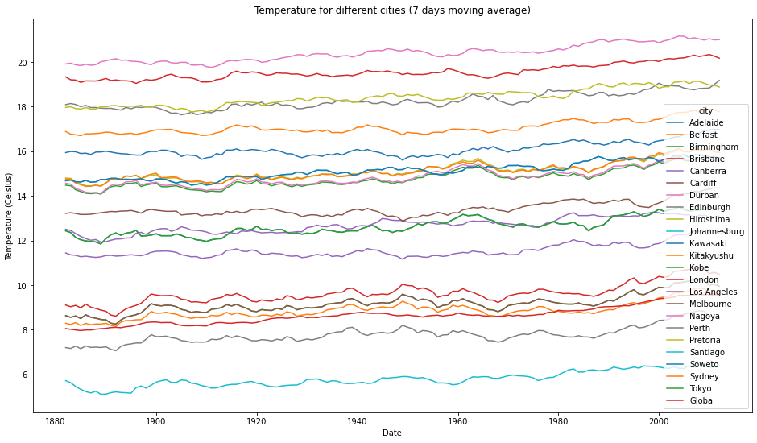

```python
# generates plot for MA7

cities_MA7.set_index('year').plot(figsize=(16, 9)
      ).set(xlabel="Date",
            ylabel="Temperature (Celsius)",
            title="Temperature for different cities (7 days moving average)")
```

[output not shown]

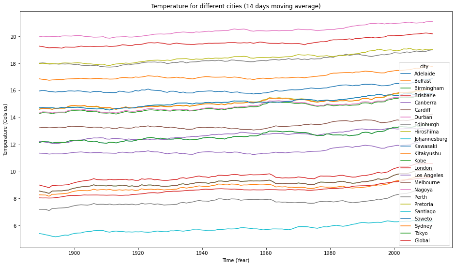

```python
# generates plot for MA14

cities_MA14.set_index('year').plot(figsize=(16, 9)
      ).set(xlabel="Time (Year)",
            ylabel="Temperature (Celsius)",
            title="Temperature for different cities (14 days moving average)")
```

```python
cities_MA7.max()
```

[output not shown]

```python
cities_MA7.min()
```

```
city
Adelaide          15.602857
Belfast            8.148571
Birmingham         8.252857
Brisbane          19.042857
Canberra          11.160000
Cardiff            8.252857
Durban            19.758571
Edinburgh          7.061429
Hiroshima         14.438571
Johannesburg      14.481429
Kawasaki          11.844286
Kitakyushu        14.425714
Kobe              14.080000
London             8.610000
Los Angeles       11.927143
Melbourne         12.865714
Nagoya            14.105714
Perth             17.635714
Pretoria          17.752857
Santiago           5.105714
Soweto            14.481429
Sydney            16.698571
Tokyo             11.844286
year            1882.000000
Global             7.964286
dtype: float64
```

Observations about the similarities and differences between the world averages and your city’s averages, as well as overall trends. Here are some questions to get you started.

#### Is your city hotter or cooler on average compared to the global average? Has the difference been consistent over time?

Santiago is the city showing the lowest temperature of all, fluctuating below the 10 degrees Celsius

#### What does the overall trend look like? Is the world getting hotter or cooler?

From this analysis we can clearly observe that global temperature is going up, and that on each country an uptrend can be seen

#### What is the hottest city?

From all five countries analysed the hottest city is present in South Africa, and corresponds to Durban

#### What are the second best?

The second coolest city is Edinburgh in United Kingdom and the second hotest is Brisbane, Australia

### In general there is no major differences between MA7 and MA14 analysis